# Лабораторная работа №16

Программный RAID

Хохлачева Полина Дмитриевна

Российский университет дружбы народов, Москва, Россия

# Информация

## Докладчик

- Хохлачева Полина Дмитриевна
- Российский университет дружбы народов
- Номер студенческого билета- 1132242473
- [1132242473@pfur.ru]

# Вводная часть

## Цель работы

Освоить работу с RAID-массивами при помощи утилиты mdadm.

## Выполнение лабораторной работы

Получаем полномочия администратора, проверка наличие дисков, создание разделов на каждом диске(рис. [-@fig:001]).

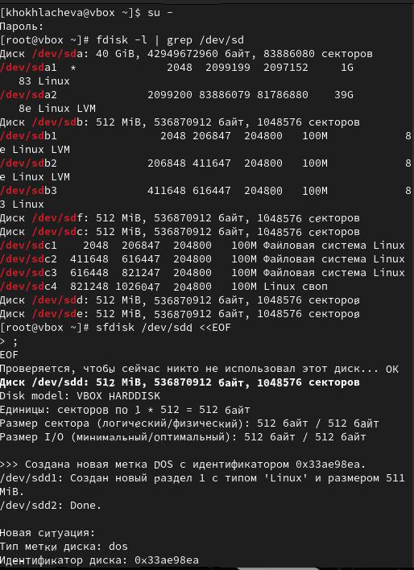

Создание

## Выполнение лабораторной работы

Разделы имеют тип 83 (стандартный Linux) ([-@fig:002]).

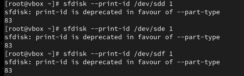

Разделы

## Выполнение лабораторной работы

Диски /dev/sdd, /dev/sde, /dev/sdf по 512 МБ, на каждом создан раздел типа fd (Linux RAID),занимают всё пространство диска (511 МБ)(рис. [-@fig:003]).

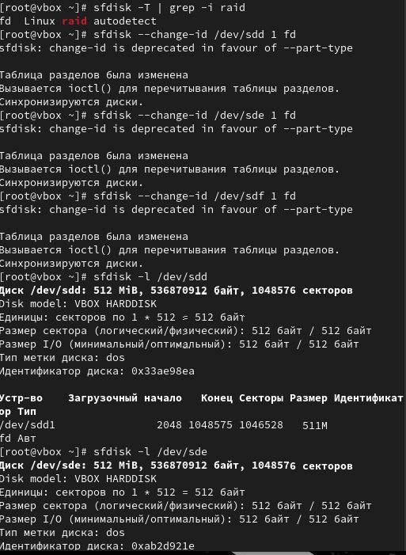

Диски

## Выполнение лабораторной работы

Создаём массив, проверяем состояние массива(рис. [-@fig:004]).

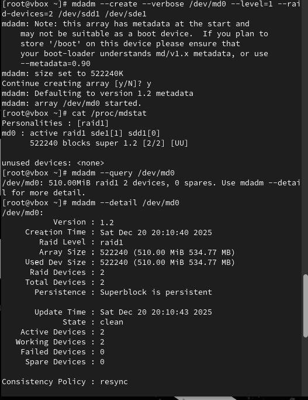

Массив

## Выполнение лабораторной работы

Добавление записи(рис. [-@fig:005]).

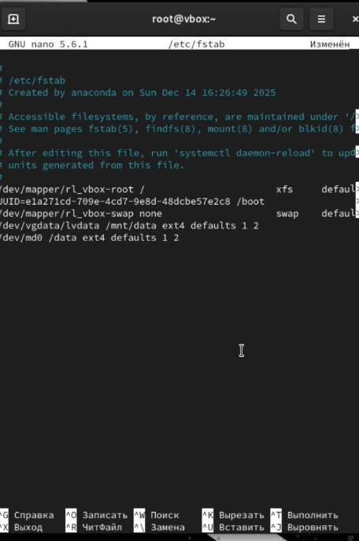

Добавление

## Выполнение лабораторной работы

Подмонтируем, добавляем запись, имитируем сбой. удаление сбойного диска, заменяем диск в массиве, удаляем массив и очищаем метаданные(рис. [-@fig:006]).

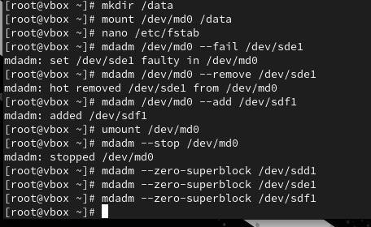

Сбой

## Выполнение лабораторной работы

Создайте массив RAID 1 из двух дисков, добавляем третий диск(рис. [-@fig:007]).

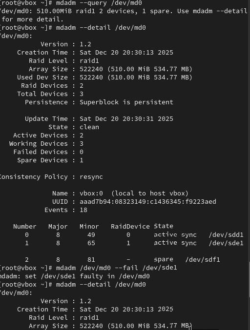

Создание

## Выполнение лабораторной работы

RAID 1 /dev/md0: Работает на 2 из 3 дисков,/dev/sde1 — сбойный,Состояние: Clean (данные доступны),Размер: 510 МБ(рис. [-@fig:008]).

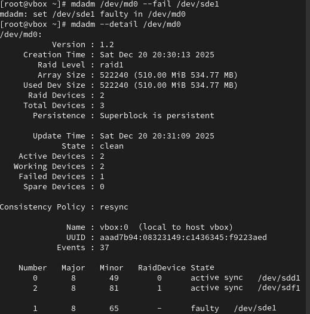

Описание

## Выполнение лабораторной работы

Сымитируем сбой одного из дисков, проверяем состояние, удаляем массив(рис. [-@fig:009]).

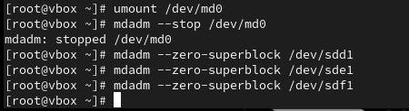

Состояние

## Выполнение лабораторной работы

Создаём массив RAID 1 из двух дисков, добавляем третий диск, подмонтирование(рис. [-@fig:009]).

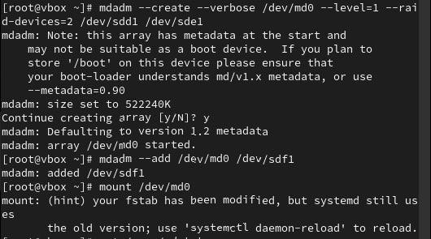

Массив

## Выполнение лабораторной работы

RAID 1 работает нормально, есть запасной диск на случай сбоя(рис. [-@fig:011]).

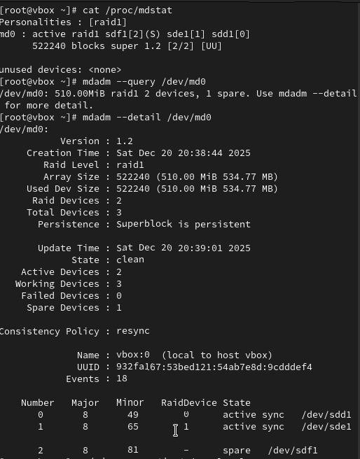

Описание

## Выполнение лабораторной работы

Изменяем тип массива RAID, Состояние массива /dev/md0:Тип изменён: с RAID 1 → RAID 5,Диски: 2 активных, 1 запасной (всего 3),Состояние: Clean (работоспособен),Размер: 510 МБ (остался прежним),RAID 5 с 2 активными дисками: Эффективность как у RAID 0 (нет избыточности),Для полноценного RAID 5 нужно минимум 3 активных диска(рис. [-@fig:012]).

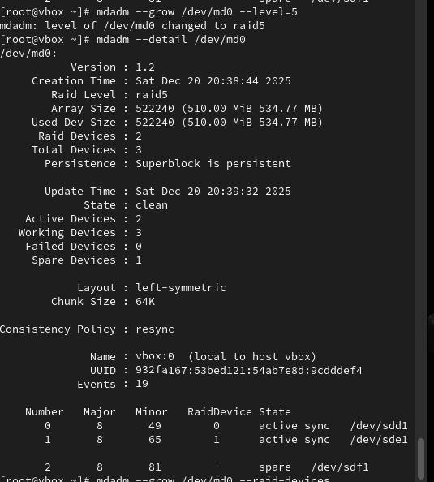

Описание

## Выполнение лабораторной работы

Состояние массива /dev/md0:Тип: RAID 5,Активные диски: 2 (/dev/sdd1, /dev/sde1),Запасной диск: 1 (/dev/sdf1),Состояние: Clean (работоспособен),Размер: 510 МБ(рис. [-@fig:013]).

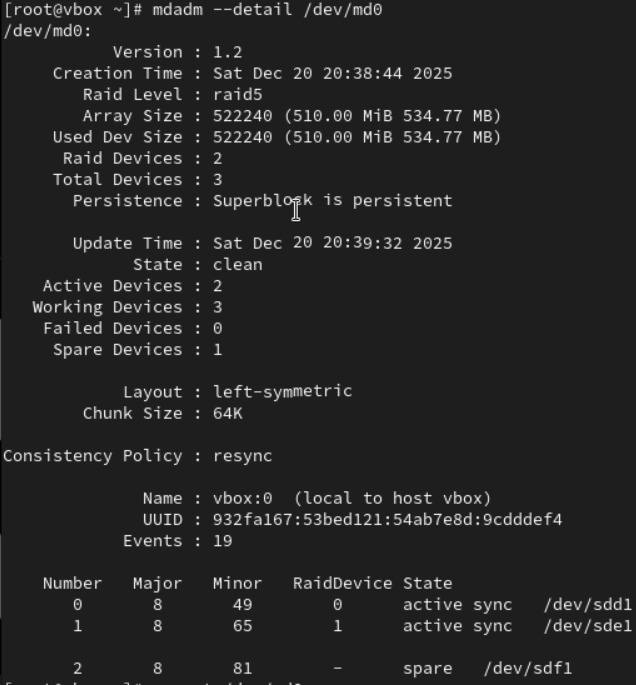

Описание

## Выполнение лабораторной работы

Удаляем массив и очищаем метаданные(рис. [-@fig:014]).

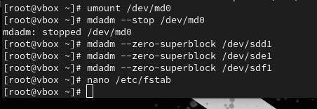

Удаление

## Выполнение лабораторной работы

Закомментирование записи в /etc/fstab(рис. [-@fig:015]).

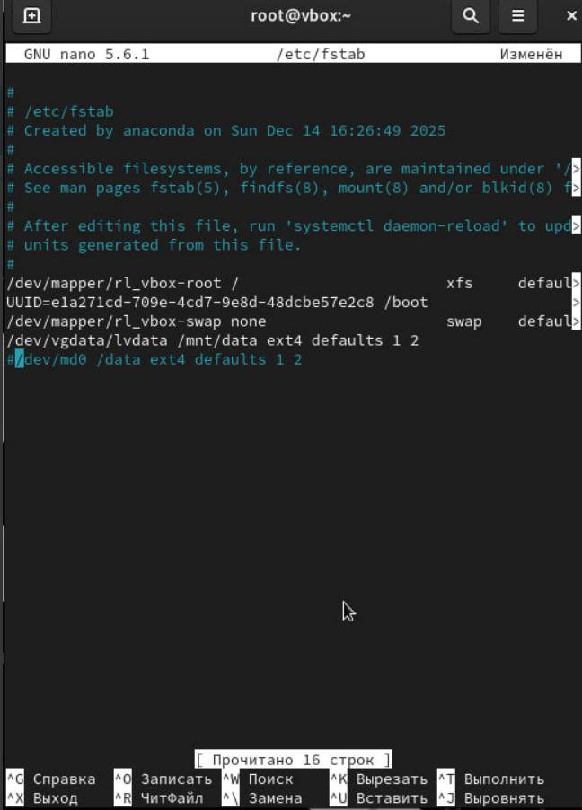

Записи

# Выводы

Мы освоили работу с RAID-массивами при помощи утилиты mdadm.